# PADP8120 Midterm Fall 2015

Victoria Coxon

# Midterm Exam

**due by class time (3:35) on October 14, 2015**

## Instructions

A. Fork the [Midterm repository](https://github.com/PADP8120-Fall2015/Midterm) from the course github page to your github account (i.e., just as you would with a homework assignment)

B. In RStudio, create a new project and link it to your newly forked github repo.

C. Resave the `Midterm_Fall2015.Rmd` file as `Midterm_Fall2015_FirstInitialLastName.Rmd` (e.g., `Midterm_Fall2015_TScott.Rmd`)

D. Complete the midterm within your `Midterm_Fall2015_FirstInitialLastName.Rmd` file.

E. Make sure your final document renders as an `.html` file.

F. Please **email** to me all of the materials necessary for another person to run your R Markdown file, including: - The R project (`.Rproj`) file - The R Markdown document (`.Rmd`) of your analyses - An HTML document (`.html`) compiled from your R Markdown document. - Any data or other files need to run the analyses in your R Markdown document.

## Guidelines

1. This is a take-home, open-book exam. This means that you are welcome to use any resources at your disposal–including textbooks, R help files, and internet resources–EXCEPTING other students (see Guideline #2).
2. However, you are expected to work alone, meaning that this exam **must not** be done as a group project or in concert with your classmates (or with the assistant of other SPIA students/faculty). The work you submit is to be yours and yours alone.
3. Your exam write-up should be clear and legible, with answers clearly indicated and work shown. Your exam must be produced in html (.html) document produced using R Markdown (i.e., an .Rmd file). Submit both your .html file and the .Rmd file used to generate it via github to the course midterm repo. If you are having trouble accomplishing this, please refer to the [guide](http://spia.uga.edu/faculty_pages/tyler.scott/teaching/PADP8120_Fall2015/Homeworks/submitting_homework.shtml).
4. The exam will be graded out of 100 points. Each problem is worth a designated number of points (shown below). Partial credit *may* by given for incorrect answers if I am able to see the process by which you went wrong (and thus see what you also did correctly), so it is to your advantage to show your work.
5. Your exam is **due by class time (3:35) on October 14, 2015**
6. Please contact me if you have any questions or concerns.

# Problems

You are asked to analyze data from a New York City school voucher experiment that a colleague and I obtained from Mathematica for a paper.

```r
nyc = read.csv("C:/Users/Victoria/Desktop/PADP 8120/Midterm_Fall2015_VCoxon/input/NYC_SchoolVoucher_Experiment.csv",row.names=1)
str(nyc)
```

```
## 'data.frame':    2666 obs. of  17 variables:
##  $ Student_ID        : int  1 21 22 25 27 28 34 42 59 83 ...
##  $ Family_ID         : int  5021 3048 5021 4720 5094 4311 3327 4860 4668 1884 ...
##  $ Date.Of.Birth     : Factor w/ 1422 levels "1983-11-11","1985-06-03",..: 119 571 766 785 85 NA 969 508 1351 1372 ...
##  $ Female            : int  1 1 0 1 1 1 0 0 0 0 ...
##  $ Grade             : int  4 3 3 2 4 4 1 3 0 0 ...
##  $ Treatment         : int  0 0 0 1 1 1 1 0 1 0 ...
##  $ Latino            : int  0 0 0 1 0 1 1 0 0 0 ...
##  $ Black             : int  1 1 1 0 0 0 0 1 1 1 ...
##  $ Eldest            : int  1 1 0 0 1 1 1 1 0 1 ...
##  $ y0_read_percentile: int  8 28 9 12 15 12 16 81 NA NA ...
##  $ y0_math_percentile: int  0 9 30 9 16 0 15 67 NA NA ...
##  $ y1_read_percentile: int  NA 25 4 16 23 1 22 84 7 27 ...
##  $ y1_math_percentile: int  NA 32 28 3 4 3 3 86 8 6 ...
##  $ y2_read_percentile: int  NA NA NA NA 31 17 6 NA 2 NA ...
##  $ y2_math_percentile: int  NA NA NA NA 27 4 10 NA 2 NA ...
##  $ y3_read_percentile: int  NA NA NA NA 42 0 32 78 27 NA ...
##  $ y3_math_percentile: int  NA NA NA NA 43 10 29 64 41 NA ...
```

```r
nyc<-read.table("C:/Users/Victoria/Desktop/PADP 8120/Midterm_Fall2015_VCoxon/input/NYC_SchoolVoucher_Experiment.csv", sep=",", header=T)
head(nyc)
```

```
##   X Student_ID Family_ID Date.Of.Birth Female Grade Treatment Latino Black
## 1 1          1      5021    1987-04-01      1     4         0      0     1
## 2 2         21      3048    1988-12-30      1     3         0      0     1
## 3 3         22      5021    1989-09-05      0     3         0      0     1
## 4 4         25      4720    1989-10-07      1     2         1      1     0
## 5 5         27      5094    1987-02-08      1     4         1      0     0
## 6 6         28      4311          <NA>      1     4         1      1     0
##   Eldest y0_read_percentile y0_math_percentile y1_read_percentile
## 1      1                  8                  0                 NA
## 2      1                 28                  9                 25
## 3      0                  9                 30                  4
## 4      0                 12                  9                 16
## 5      1                 15                 16                 23
## 6      1                 12                  0                  1
##   y1_math_percentile y2_read_percentile y2_math_percentile
## 1                 NA                 NA                 NA
## 2                 32                 NA                 NA
## 3                 28                 NA                 NA
## 4                  3                 NA                 NA
## 5                  4                 31                 27
## 6                  3                 17                  4
##   y3_read_percentile y3_math_percentile
## 1                 NA                 NA
## 2                 NA                 NA
## 3                 NA                 NA
## 4                 NA                 NA
## 5                 42                 43
## 6                  0                 10
```

```r
str(nyc)
```

```
## 'data.frame':    2666 obs. of  18 variables:
##  $ X                 : int  1 2 3 4 5 6 7 8 9 10 ...
##  $ Student_ID        : int  1 21 22 25 27 28 34 42 59 83 ...
##  $ Family_ID         : int  5021 3048 5021 4720 5094 4311 3327 4860 4668 1884 ...
##  $ Date.Of.Birth     : Factor w/ 1422 levels "1983-11-11","1985-06-03",..: 119 571 766 785 85 NA 969 508 1351 1372 ...
##  $ Female            : int  1 1 0 1 1 1 0 0 0 0 ...
##  $ Grade             : int  4 3 3 2 4 4 1 3 0 0 ...
##  $ Treatment         : int  0 0 0 1 1 1 1 0 1 0 ...
##  $ Latino            : int  0 0 0 1 0 1 1 0 0 0 ...
##  $ Black             : int  1 1 1 0 0 0 0 1 1 1 ...
##  $ Eldest            : int  1 1 0 0 1 1 1 1 0 1 ...
##  $ y0_read_percentile: int  8 28 9 12 15 12 16 81 NA NA ...
##  $ y0_math_percentile: int  0 9 30 9 16 0 15 67 NA NA ...
##  $ y1_read_percentile: int  NA 25 4 16 23 1 22 84 7 27 ...
##  $ y1_math_percentile: int  NA 32 28 3 4 3 3 86 8 6 ...
##  $ y2_read_percentile: int  NA NA NA NA 31 17 6 NA 2 NA ...
##  $ y2_math_percentile: int  NA NA NA NA 27 4 10 NA 2 NA ...
##  $ y3_read_percentile: int  NA NA NA NA 42 0 32 78 27 NA ...
##  $ y3_math_percentile: int  NA NA NA NA 43 10 29 64 41 NA ...
```

There are 2666 observations of 18 variables.

Most of the variables you need should be pretty self explanatory:

| Variable | Description |
| --- | --- |
| `Student_ID` | numerical code for each student |
| `Family_ID` | numerical code for each family |
| `Date.Of.Birth` | student birthday |
| `Female` | binary indicator for female students; 1 = female, 0 = male |
| `Grade` | student grade level when starting experiment |
| `Treatment` | binary indicator for whether student received voucher; 1 = Voucher Treatment, 0 = No Voucher |
| `Latino` | binary indicator for Latino students; 1 = Latino, 0 = Otherwise |
| `Black` | binary indicator for black students; 1 = Black, 0 = Otherwise |
| `Eldest` | binary indicator for eldest children; 1 = Eldest, 0 = Otherwise |
| `y0_read_percentile` | pre-test reading score percentile |
| `y0_math_percentile` | pre-test math score percentile |
| `y1_read_percentile` | reading score percentile after 1y |
| `y1_math_percentile` | math score percentile after 1y |
| `y2_read_percentile` | reading score percentile after 2y |
| `y2_math_percentile` | math score percentile after 2y |
| `y3_read_percentile` | reading score percentile after 3y |
| `y3_math_percentile` | math score percentile after 3y |

**1. (6 points) Compute the average reading and math percentiles for each year across all students.**

```r
library(knitr)
summary(nyc$y0_read_percentile)
```

```
##    Min. 1st Qu.  Median    Mean 3rd Qu.    Max.    NA's
##    0.00    4.00   16.00   22.78   34.00   99.00     815
```

```r
summary(nyc$y0_math_percentile)
```

```
##    Min. 1st Qu.  Median    Mean 3rd Qu.    Max.    NA's
##    0.00    1.00    9.00   16.54   25.00   98.00     815
```

```r
summary(nyc$y1_read_percentile)
```

```
##    Min. 1st Qu.  Median    Mean 3rd Qu.    Max.    NA's
##    0.00    8.00   20.00   26.06   40.00   97.00     586
```

```r
summary(nyc$y1_math_percentile)
```

```
##    Min. 1st Qu.  Median    Mean 3rd Qu.    Max.    NA's
##     0.0     5.0    15.0    22.3    34.0    99.0     586
```

```r
summary(nyc$y2_read_percentile)
```

```
##    Min. 1st Qu.  Median    Mean 3rd Qu.    Max.    NA's
##    0.00    8.00   21.00   26.09   39.00   99.00     912
```

```r
summary(nyc$y2_math_percentile)
```

```
##    Min. 1st Qu.  Median    Mean 3rd Qu.    Max.    NA's
##    0.00    5.00   16.00   23.56   37.00   99.00     912
```

```r
summary(nyc$y3_read_percentile)
```

```
##    Min. 1st Qu.  Median    Mean 3rd Qu.    Max.    NA's
##    0.00   20.00   33.00   32.63   44.00   95.00     865
```

```r
summary(nyc$y3_math_percentile)
```

```
##    Min. 1st Qu.  Median    Mean 3rd Qu.    Max.    NA's
##     0.0    20.0    32.0    32.5    45.0    99.0     865
```

| nyc_Year | Min. | 1st Qu. | Median | Mean | 3rd Qu. | Max. | NA’s |
| --- | --- | --- | --- | --- | --- | --- | --- |
| y0_read_percentile | 0.00 | 4.00 | 16.00 | 22.78 | 34.00 | 99.00 | 815 |
| y0_math_percentile | 0.00 | 1.00 | 9.00 | 16.54 | 25.00 | 98.00 | 815 |
| y1_read_percentile | 0.00 | 8.00 | 20.00 | 26.06 | 40.00 | 97.00 | 586 |
| y1_math_percentile | 0.0 | 5.0 | 15.0 | 22.3 | 34.0 | 99.0 | 586 |
| y2_read_percentile | 0.00 | 8.00 | 21.00 | 26.09 | 39.00 | 99.00 | 912 |
| y2_math_percentile | 0.00 | 5.00 | 16.00 | 23.56 | 37.00 | 99.00 | 912 |
| y3_read_percentile | 0.00 | 20.00 | 33.00 | 32.63 | 44.00 | 95.00 | 865 |
| y3_math_percentile | 0.0 | 20.0 | 32.0 | 32.5 | 45.0 | 99.0 | 865 |

```r
library(dplyr)
```

```r
library(ggplot2)
library(pastecs)
attach(nyc)
scores <- cbind(y0_read_percentile, y0_math_percentile, y1_read_percentile, y1_math_percentile, y2_read_percentile, y2_math_percentile, y3_read_percentile, y3_math_percentile)
stat.desc(scores)
```

```
##              y0_read_percentile y0_math_percentile y1_read_percentile
## nbr.val            1.851000e+03       1.851000e+03       2.080000e+03
## nbr.null           1.990000e+02       3.240000e+02       8.800000e+01
## nbr.na             8.150000e+02       8.150000e+02       5.860000e+02
## min                0.000000e+00       0.000000e+00       0.000000e+00
## max                9.900000e+01       9.800000e+01       9.700000e+01
## range              9.900000e+01       9.800000e+01       9.700000e+01
## sum                4.217100e+04       3.062000e+04       5.419700e+04
## median             1.600000e+01       9.000000e+00       2.000000e+01
## mean               2.278282e+01       1.654241e+01       2.605625e+01
## SE.mean            5.083727e-01       4.528975e-01       4.929922e-01
## CI.mean.0.95       9.970445e-01       8.882439e-01       9.668098e-01
## var                4.783777e+02       3.796700e+02       5.055259e+02
## std.dev            2.187185e+01       1.948512e+01       2.248390e+01
## coef.var           9.600149e-01       1.177889e+00       8.628987e-01
##              y1_math_percentile y2_read_percentile y2_math_percentile
## nbr.val            2.080000e+03       1.754000e+03       1.754000e+03
## nbr.null           1.030000e+02       5.700000e+01       1.280000e+02
## nbr.na             5.860000e+02       9.120000e+02       9.120000e+02
## min                0.000000e+00       0.000000e+00       0.000000e+00
## max                9.900000e+01       9.900000e+01       9.900000e+01
## range              9.900000e+01       9.900000e+01       9.900000e+01
## sum                4.637700e+04       4.576500e+04       4.132200e+04
## median             1.500000e+01       2.100000e+01       1.600000e+01
## mean               2.229663e+01       2.609179e+01       2.355872e+01
## SE.mean            4.788753e-01       5.176809e-01       5.403636e-01
## CI.mean.0.95       9.391252e-01       1.015337e+00       1.059825e+00
## var                4.769889e+02       4.700606e+02       5.121554e+02
## std.dev            2.184008e+01       2.168088e+01       2.263085e+01
## coef.var           9.795234e-01       8.309465e-01       9.606145e-01
##              y3_read_percentile y3_math_percentile
## nbr.val            1.801000e+03       1.801000e+03
## nbr.null           5.800000e+01       6.700000e+01
## nbr.na             8.650000e+02       8.650000e+02
## min                0.000000e+00       0.000000e+00
## max                9.500000e+01       9.900000e+01
## range              9.500000e+01       9.900000e+01
## sum                5.877500e+04       5.853500e+04
## median             3.300000e+01       3.200000e+01
## mean               3.263465e+01       3.250139e+01
## SE.mean            4.088356e-01       4.274376e-01
## CI.mean.0.95       8.018422e-01       8.383260e-01
## var                3.010309e+02       3.290479e+02
## std.dev            1.735024e+01       1.813968e+01
## coef.var           5.316510e-01       5.581201e-01
```

```r
options(scipen=100)
stat.desc(scores)
```

```
##              y0_read_percentile y0_math_percentile y1_read_percentile
## nbr.val            1851.0000000       1851.0000000       2080.0000000
## nbr.null            199.0000000        324.0000000         88.0000000
## nbr.na              815.0000000        815.0000000        586.0000000
## min                   0.0000000          0.0000000          0.0000000
## max                  99.0000000         98.0000000         97.0000000
## range                99.0000000         98.0000000         97.0000000
## sum               42171.0000000      30620.0000000      54197.0000000
## median               16.0000000          9.0000000         20.0000000
## mean                 22.7828201         16.5424095         26.0562500
## SE.mean               0.5083727          0.4528975          0.4929922
## CI.mean.0.95          0.9970445          0.8882439          0.9668098
## var                 478.3776723        379.6699572        505.5259349
## std.dev              21.8718466         19.4851214         22.4839039
## coef.var              0.9600149          1.1778890          0.8628987
##              y1_math_percentile y2_read_percentile y2_math_percentile
## nbr.val            2080.0000000       1754.0000000       1754.0000000
## nbr.null            103.0000000         57.0000000        128.0000000
## nbr.na              586.0000000        912.0000000        912.0000000
## min                   0.0000000          0.0000000          0.0000000
## max                  99.0000000         99.0000000         99.0000000
## range                99.0000000         99.0000000         99.0000000
## sum               46377.0000000      45765.0000000      41322.0000000
## median               15.0000000         21.0000000         16.0000000
## mean                 22.2966346         26.0917902         23.5587229
## SE.mean               0.4788753          0.5176809          0.5403636
## CI.mean.0.95          0.9391252          1.0153369          1.0598250
## var                 476.9889257        470.0605943        512.1554202
## std.dev              21.8400761         21.6808808         22.6308511
## coef.var              0.9795234          0.8309465          0.9606145
##              y3_read_percentile y3_math_percentile
## nbr.val            1801.0000000       1801.0000000
## nbr.null             58.0000000         67.0000000
## nbr.na              865.0000000        865.0000000
## min                   0.0000000          0.0000000
## max                  95.0000000         99.0000000
## range                95.0000000         99.0000000
## sum               58775.0000000      58535.0000000
## median               33.0000000         32.0000000
## mean                 32.6346474         32.5013881
## SE.mean               0.4088356          0.4274376
## CI.mean.0.95          0.8018422          0.8383260
## var                 301.0308878        329.0479147
## std.dev              17.3502417         18.1396779
## coef.var              0.5316510          0.5581201
```

```r
stat.desc(scores, basic=F)
```

```
##              y0_read_percentile y0_math_percentile y1_read_percentile
## median               16.0000000          9.0000000         20.0000000
## mean                 22.7828201         16.5424095         26.0562500
## SE.mean               0.5083727          0.4528975          0.4929922
## CI.mean.0.95          0.9970445          0.8882439          0.9668098
## var                 478.3776723        379.6699572        505.5259349
## std.dev              21.8718466         19.4851214         22.4839039
## coef.var              0.9600149          1.1778890          0.8628987
##              y1_math_percentile y2_read_percentile y2_math_percentile
## median               15.0000000         21.0000000         16.0000000
## mean                 22.2966346         26.0917902         23.5587229
## SE.mean               0.4788753          0.5176809          0.5403636
## CI.mean.0.95          0.9391252          1.0153369          1.0598250
## var                 476.9889257        470.0605943        512.1554202
## std.dev              21.8400761         21.6808808         22.6308511
## coef.var              0.9795234          0.8309465          0.9606145
##              y3_read_percentile y3_math_percentile
## median               33.0000000         32.0000000
## mean                 32.6346474         32.5013881
## SE.mean               0.4088356          0.4274376
## CI.mean.0.95          0.8018422          0.8383260
## var                 301.0308878        329.0479147
## std.dev              17.3502417         18.1396779
## coef.var              0.5316510          0.5581201
```

```r
# Method adapted from http://www.ats.ucla.edu/stat/r/faq/basic_desc.htm
#The problems with the attach function are known, but the ease with which to obtain the statistics is compelling.
#I compared the means derived from the summary function with those derived from using the cluster of commands beginning with the attach() function to make sure I wasn't missing anything. They are consistent.
```

The mean scores for reading and mathematics are as follows:

| Reading | Mathematics |
| --- | --- |
| Reading Year 0 = 22.78 | Mathematics Year 0 = 16.54 |
| Reading Year 1 = 26.06 | Mathematics Year 1 = 22.30 |
| Reading Year 2 = 26.09 | Mathematics Year 2 = 23.56 |
| Reading Year 3 = 32.63 | Mathematics Year 3 = 32.50 |

**2. (4 points) Clean the original dataset by removing all students who do not have observed pre-test scores and year 1 scores for reading and for math.**

```r
stat.desc(scores, desc=F)
```

```
##          y0_read_percentile y0_math_percentile y1_read_percentile
## nbr.val                1851               1851               2080
## nbr.null                199                324                 88
## nbr.na                  815                815                586
## min                       0                  0                  0
## max                      99                 98                 97
## range                    99                 98                 97
## sum                   42171              30620              54197
##          y1_math_percentile y2_read_percentile y2_math_percentile
## nbr.val                2080               1754               1754
## nbr.null                103                 57                128
## nbr.na                  586                912                912
## min                       0                  0                  0
## max                      99                 99                 99
## range                    99                 99                 99
## sum                   46377              45765              41322
##          y3_read_percentile y3_math_percentile
## nbr.val                1801               1801
## nbr.null                 58                 67
## nbr.na                  865                865
## min                       0                  0
## max                      95                 99
## range                    95                 99
## sum                   58775              58535
```

```r
# x <- airquality[complete.cases(airquality), ]
clean.nyc <- filter(nyc, y0_read_percentile!='NA', y0_math_percentile!='NA', y1_read_percentile!='NA', y1_math_percentile!='NA')
str(clean.nyc)
```

```
## 'data.frame':    1455 obs. of  18 variables:
##  $ X                 : int  2 3 4 5 6 7 8 13 14 16 ...
##  $ Student_ID        : int  21 22 25 27 28 34 42 140 151 177 ...
##  $ Family_ID         : int  3048 5021 4720 5094 4311 3327 4860 4721 3623 2619 ...
##  $ Date.Of.Birth     : Factor w/ 1422 levels "1983-11-11","1985-06-03",..: 571 766 785 85 NA 969 508 963 630 494 ...
##  $ Female            : int  1 0 1 1 1 0 0 0 1 0 ...
##  $ Grade             : int  3 3 2 4 4 1 3 1 2 3 ...
##  $ Treatment         : int  0 0 1 1 1 1 0 0 0 0 ...
##  $ Latino            : int  0 0 1 0 1 1 0 1 1 0 ...
##  $ Black             : int  1 1 0 0 0 0 1 0 0 1 ...
##  $ Eldest            : int  1 0 0 1 1 1 1 0 0 1 ...
##  $ y0_read_percentile: int  28 9 12 15 12 16 81 29 27 8 ...
##  $ y0_math_percentile: int  9 30 9 16 0 15 67 5 13 11 ...
##  $ y1_read_percentile: int  25 4 16 23 1 22 84 22 25 0 ...
##  $ y1_math_percentile: int  32 28 3 4 3 3 86 37 43 23 ...
##  $ y2_read_percentile: int  NA NA NA 31 17 6 NA 25 NA 7 ...
##  $ y2_math_percentile: int  NA NA NA 27 4 10 NA 37 NA 25 ...
##  $ y3_read_percentile: int  NA NA NA 42 0 32 78 29 NA NA ...
##  $ y3_math_percentile: int  NA NA NA 43 10 29 64 53 NA NA ...
```

```r
head(clean.nyc)
```

```
##   X Student_ID Family_ID Date.Of.Birth Female Grade Treatment Latino Black
## 1 2         21      3048    1988-12-30      1     3         0      0     1
## 2 3         22      5021    1989-09-05      0     3         0      0     1
## 3 4         25      4720    1989-10-07      1     2         1      1     0
## 4 5         27      5094    1987-02-08      1     4         1      0     0
## 5 6         28      4311          <NA>      1     4         1      1     0
## 6 7         34      3327    1990-06-27      0     1         1      1     0
##   Eldest y0_read_percentile y0_math_percentile y1_read_percentile
## 1      1                 28                  9                 25
## 2      0                  9                 30                  4
## 3      0                 12                  9                 16
## 4      1                 15                 16                 23
## 5      1                 12                  0                  1
## 6      1                 16                 15                 22
##   y1_math_percentile y2_read_percentile y2_math_percentile
## 1                 32                 NA                 NA
## 2                 28                 NA                 NA
## 3                  3                 NA                 NA
## 4                  4                 31                 27
## 5                  3                 17                  4
## 6                  3                  6                 10
##   y3_read_percentile y3_math_percentile
## 1                 NA                 NA
## 2                 NA                 NA
## 3                 NA                 NA
## 4                 42                 43
## 5                  0                 10
## 6                 32                 29
```

```r
summary(clean.nyc$y0_read_percentile)
```

```
##    Min. 1st Qu.  Median    Mean 3rd Qu.    Max.
##    0.00    4.00   16.00   22.57   34.00   99.00
```

```r
summary(clean.nyc$y0_math_percentile)
```

```
##    Min. 1st Qu.  Median    Mean 3rd Qu.    Max.
##    0.00    2.00    9.00   16.42   25.00   98.00
```

```r
summary(clean.nyc$y1_read_percentile)
```

```
##    Min. 1st Qu.  Median    Mean 3rd Qu.    Max.
##    0.00    7.00   18.00   24.63   37.50   97.00
```

```r
summary(clean.nyc$y1_math_percentile)
```

```
##    Min. 1st Qu.  Median    Mean 3rd Qu.    Max.
##    0.00    5.00   15.00   23.24   36.00   99.00
```

```r
summary(clean.nyc$y2_read_percentile)
```

```
##    Min. 1st Qu.  Median    Mean 3rd Qu.    Max.    NA's
##    0.00    8.00   20.00   25.26   38.00   98.00     343
```

```r
summary(clean.nyc$y2_math_percentile)
```

```
##    Min. 1st Qu.  Median    Mean 3rd Qu.    Max.    NA's
##    0.00    5.00   16.00   24.24   37.00   99.00     343
```

```r
summary(clean.nyc$y3_read_percentile)
```

```
##    Min. 1st Qu.  Median    Mean 3rd Qu.    Max.    NA's
##    0.00   21.00   34.00   33.54   46.00   95.00     333
```

```r
summary(clean.nyc$y3_math_percentile)
```

```
##    Min. 1st Qu.  Median    Mean 3rd Qu.    Max.    NA's
##    0.00   21.00   32.00   33.23   45.00   99.00     333
```

[output not shown]

```r
attach(clean.nyc)
clean.scores <- cbind(y0_read_percentile, y0_math_percentile, y1_read_percentile, y1_math_percentile, y2_read_percentile, y2_math_percentile, y3_read_percentile, y3_math_percentile)
stat.desc(scores)
```

```
##              y0_read_percentile y0_math_percentile y1_read_percentile
## nbr.val            1851.0000000       1851.0000000       2080.0000000
## nbr.null            199.0000000        324.0000000         88.0000000
## nbr.na              815.0000000        815.0000000        586.0000000
## min                   0.0000000          0.0000000          0.0000000
## max                  99.0000000         98.0000000         97.0000000
## range                99.0000000         98.0000000         97.0000000
## sum               42171.0000000      30620.0000000      54197.0000000
## median               16.0000000          9.0000000         20.0000000
## mean                 22.7828201         16.5424095         26.0562500
## SE.mean               0.5083727          0.4528975          0.4929922
## CI.mean.0.95          0.9970445          0.8882439          0.9668098
## var                 478.3776723        379.6699572        505.5259349
## std.dev              21.8718466         19.4851214         22.4839039
## coef.var              0.9600149          1.1778890          0.8628987
##              y1_math_percentile y2_read_percentile y2_math_percentile
## nbr.val            2080.0000000       1754.0000000       1754.0000000
## nbr.null            103.0000000         57.0000000        128.0000000
## nbr.na              586.0000000        912.0000000        912.0000000
## min                   0.0000000          0.0000000          0.0000000
## max                  99.0000000         99.0000000         99.0000000
## range                99.0000000         99.0000000         99.0000000
## sum               46377.0000000      45765.0000000      41322.0000000
## median               15.0000000         21.0000000         16.0000000
## mean                 22.2966346         26.0917902         23.5587229
## SE.mean               0.4788753          0.5176809          0.5403636
## CI.mean.0.95          0.9391252          1.0153369          1.0598250
## var                 476.9889257        470.0605943        512.1554202
## std.dev              21.8400761         21.6808808         22.6308511
## coef.var              0.9795234          0.8309465          0.9606145
##              y3_read_percentile y3_math_percentile
## nbr.val            1801.0000000       1801.0000000
## nbr.null             58.0000000         67.0000000
## nbr.na              865.0000000        865.0000000
## min                   0.0000000          0.0000000
## max                  95.0000000         99.0000000
## range                95.0000000         99.0000000
## sum               58775.0000000      58535.0000000
## median               33.0000000         32.0000000
## mean                 32.6346474         32.5013881
## SE.mean               0.4088356          0.4274376
## CI.mean.0.95          0.8018422          0.8383260
## var                 301.0308878        329.0479147
## std.dev              17.3502417         18.1396779
## coef.var              0.5316510          0.5581201
```

```r
options(scipen=100)
stat.desc(clean.scores)
```

```
##              y0_read_percentile y0_math_percentile y1_read_percentile
## nbr.val            1455.0000000       1455.0000000       1455.0000000
## nbr.null            159.0000000        258.0000000         50.0000000
## nbr.na                0.0000000          0.0000000          0.0000000
## min                   0.0000000          0.0000000          0.0000000
## max                  99.0000000         98.0000000         97.0000000
## range                99.0000000         98.0000000         97.0000000
## sum               32836.0000000      23889.0000000      35834.0000000
## median               16.0000000          9.0000000         18.0000000
## mean                 22.5676976         16.4185567         24.6281787
## SE.mean               0.5654082          0.5035625          0.5616962
## CI.mean.0.95          1.1091030          0.9877867          1.1018215
## var                 465.1437977        368.9519250        459.0562893
## std.dev              21.5671926         19.2081213         21.4255989
## coef.var              0.9556665          1.1699032          0.8699628
##              y1_math_percentile y2_read_percentile y2_math_percentile
## nbr.val            1455.0000000       1112.0000000       1112.0000000
## nbr.null             80.0000000         29.0000000         89.0000000
## nbr.na                0.0000000        343.0000000        343.0000000
## min                   0.0000000          0.0000000          0.0000000
## max                  99.0000000         98.0000000         99.0000000
## range                99.0000000         98.0000000         99.0000000
## sum               33810.0000000      28087.0000000      26959.0000000
## median               15.0000000         20.0000000         16.0000000
## mean                 23.2371134         25.2580935         24.2437050
## SE.mean               0.5932666          0.6274032          0.6972398
## CI.mean.0.95          1.1637499          1.2310287          1.3680552
## var                 512.1094882        437.7218066        540.5913195
## std.dev              22.6298362         20.9218022         23.2506198
## coef.var              0.9738661          0.8283207          0.9590374
##              y3_read_percentile y3_math_percentile
## nbr.val            1122.0000000       1122.0000000
## nbr.null             35.0000000         32.0000000
## nbr.na              333.0000000        333.0000000
## min                   0.0000000          0.0000000
## max                  95.0000000         99.0000000
## range                95.0000000         99.0000000
## sum               37630.0000000      37286.0000000
## median               34.0000000         32.0000000
## mean                 33.5383244         33.2317291
## SE.mean               0.5218483          0.5349397
## CI.mean.0.95          1.0239094          1.0495957
## var                 305.5493774        321.0720343
## std.dev              17.4799707         17.9184830
## coef.var              0.5211939          0.5391980
```

```r
stat.desc(clean.scores, basic=F)
```

```
##              y0_read_percentile y0_math_percentile y1_read_percentile
## median               16.0000000          9.0000000         18.0000000
## mean                 22.5676976         16.4185567         24.6281787
## SE.mean               0.5654082          0.5035625          0.5616962
## CI.mean.0.95          1.1091030          0.9877867          1.1018215
## var                 465.1437977        368.9519250        459.0562893
## std.dev              21.5671926         19.2081213         21.4255989
## coef.var              0.9556665          1.1699032          0.8699628
##              y1_math_percentile y2_read_percentile y2_math_percentile
## median               15.0000000         20.0000000         16.0000000
## mean                 23.2371134         25.2580935         24.2437050
## SE.mean               0.5932666          0.6274032          0.6972398
## CI.mean.0.95          1.1637499          1.2310287          1.3680552
## var                 512.1094882        437.7218066        540.5913195
## std.dev              22.6298362         20.9218022         23.2506198
## coef.var              0.9738661          0.8283207          0.9590374
##              y3_read_percentile y3_math_percentile
## median               34.0000000         32.0000000
## mean                 33.5383244         33.2317291
## SE.mean               0.5218483          0.5349397
## CI.mean.0.95          1.0239094          1.0495957
## var                 305.5493774        321.0720343
## std.dev              17.4799707         17.9184830
## coef.var              0.5211939          0.5391980
```

I cleaned the data and then checked to see if there was a difference in the summary statistics based on the scores from the cleaned data. There is a difference, as would be expected when missing observations are dropped. Dropping observations with missing values effectively lowered the sample size from 2666 observations to 1455 observations. We might want to be a little more cautious in any inferences we make from this data. Reading Year 0 = 22.78; Clean = 22.57 Mathematics Year 0 = 16.54; Clean = 16.42  
Reading Year 1 = 26.06; Clean = 24.63 Mathematics Year 1 = 22.30; Clean = 23.24 Reading Year 2 = 26.09; Clean = 25.26 Mathematics Year 2 = 23.56; Clean = 24.24 Reading Year 3 = 32.63; Clean = 33.54 Mathematics Year 3 = 32.50; Clean = 33.23

**3. (8 points) Make a figure (either a density plot of a histgram format) comparing the distributions of percentile reading scores for students who did and did not receive a voucher. Do your best to make the figure “publishable” by giving it clear axis titles, legend labels, and other aesthetic improvements.**

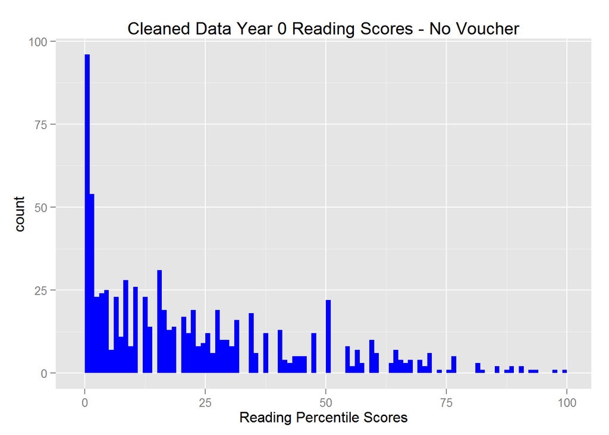

```r
clean.no.vouch <- filter(clean.nyc,Treatment=="1")
clean.vouch <- filter(clean.nyc,Treatment=="0")
qplot(clean.no.vouch$y0_read_percentile,geom = "histogram", binwidth = 1.0, main = "Cleaned Data Year 0 Reading Scores - No Voucher", xlab = "Reading Percentile Scores", fill=I("blue"))
```

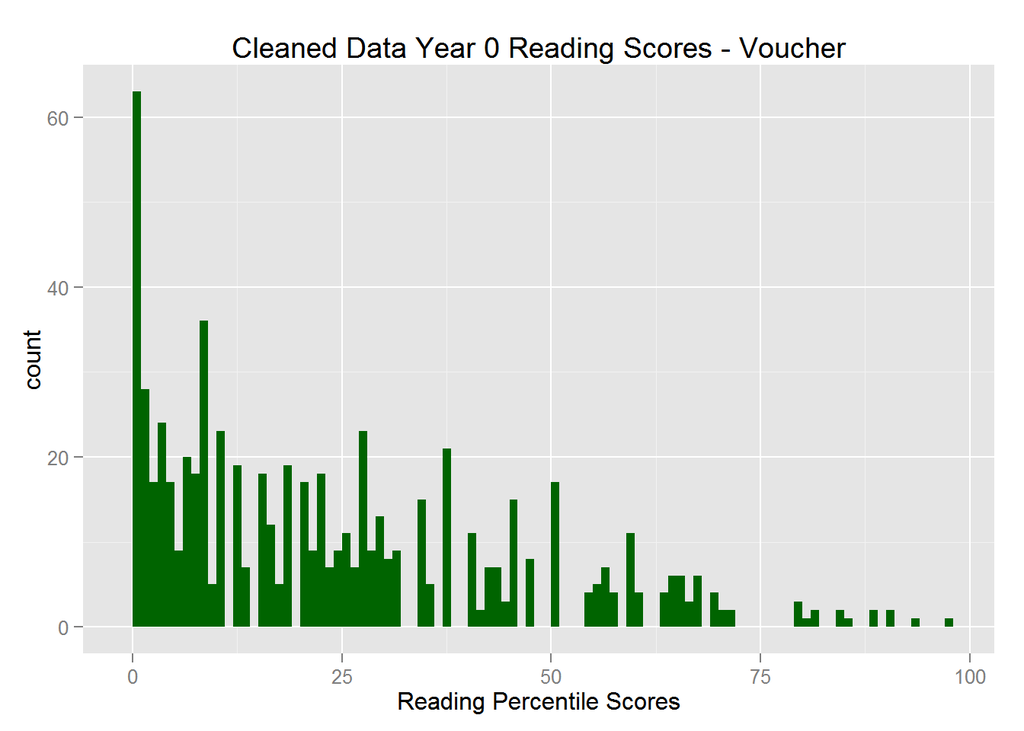

```r
qplot(clean.vouch$y0_read_percentile,geom = "histogram", binwidth = 1.0, main = "Cleaned Data Year 0 Reading Scores - Voucher", xlab = "Reading Percentile Scores", fill=I("darkgreen"))
```

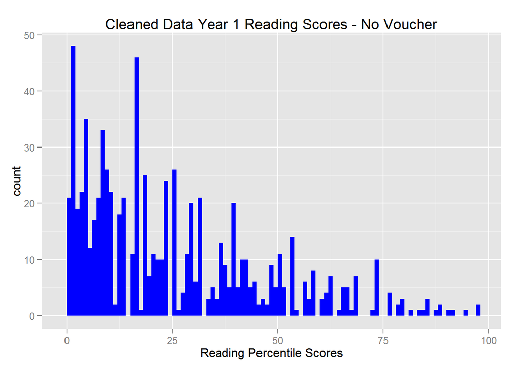

```r
qplot(clean.no.vouch$y1_read_percentile,geom = "histogram", binwidth = 1.0, main = "Cleaned Data Year 1 Reading Scores - No Voucher", xlab = "Reading Percentile Scores", fill=I("blue"))
```

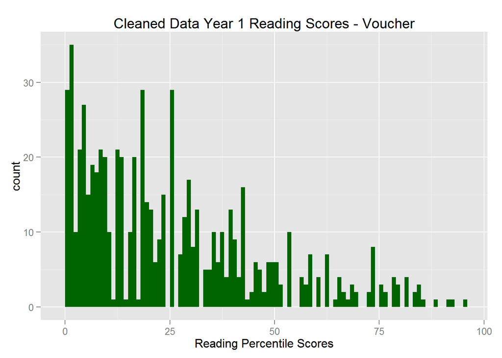

```r
qplot(clean.vouch$y1_read_percentile,geom = "histogram", binwidth = 1.0, main = "Cleaned Data Year 1 Reading Scores - Voucher", xlab = "Reading Percentile Scores", fill=I("darkgreen"))
```

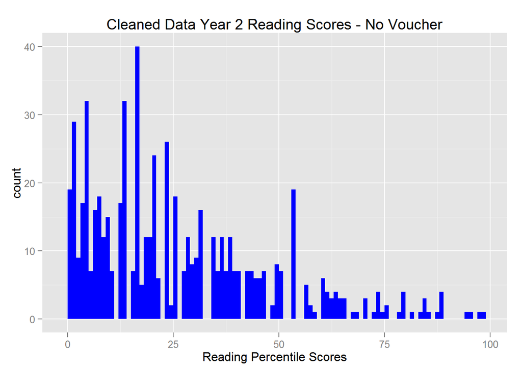

```r
qplot(clean.no.vouch$y2_read_percentile,geom = "histogram", binwidth = 1.0, main = "Cleaned Data Year 2 Reading Scores - No Voucher", xlab = "Reading Percentile Scores", fill=I("blue"))
```

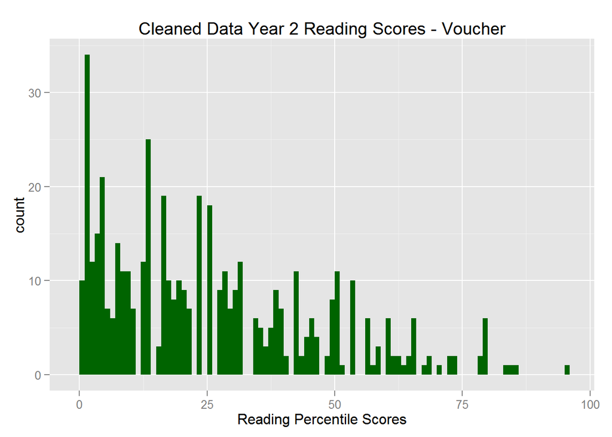

```r
qplot(clean.vouch$y2_read_percentile,geom = "histogram", binwidth = 1.0, main = "Cleaned Data Year 2 Reading Scores - Voucher", xlab = "Reading Percentile Scores", fill=I("darkgreen"))
```

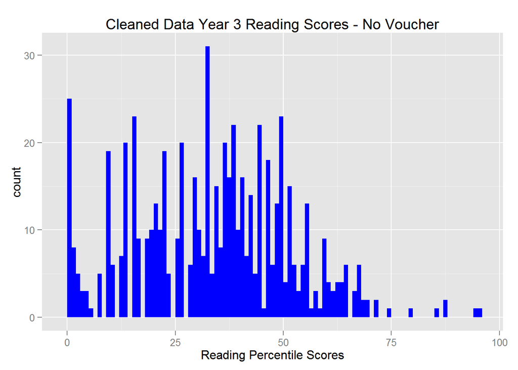

```r
qplot(clean.no.vouch$y3_read_percentile,geom = "histogram", binwidth = 1.0, main = "Cleaned Data Year 3 Reading Scores - No Voucher", xlab = "Reading Percentile Scores", fill=I("blue"))
```

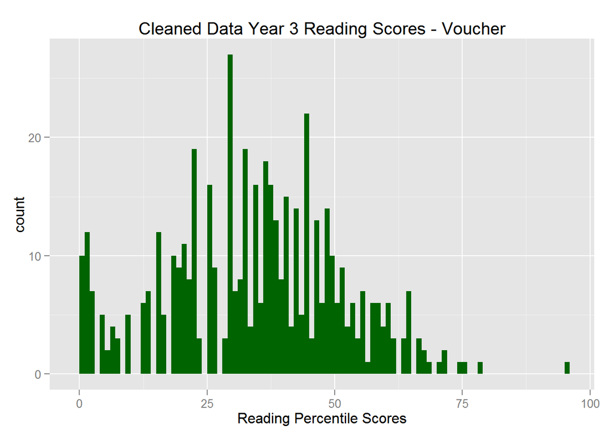

```r
qplot(clean.vouch$y3_read_percentile,geom = "histogram", binwidth = 1.0, main = "Cleaned Data Year 3 Reading Scores - Voucher", xlab = "Reading Percentile Scores", fill=I("darkgreen"))
```

These were done with the cleaned data. Now I want to look at the original “dirty” data to see if the right skew is still there. If so, I have concerns about applying the normal model.

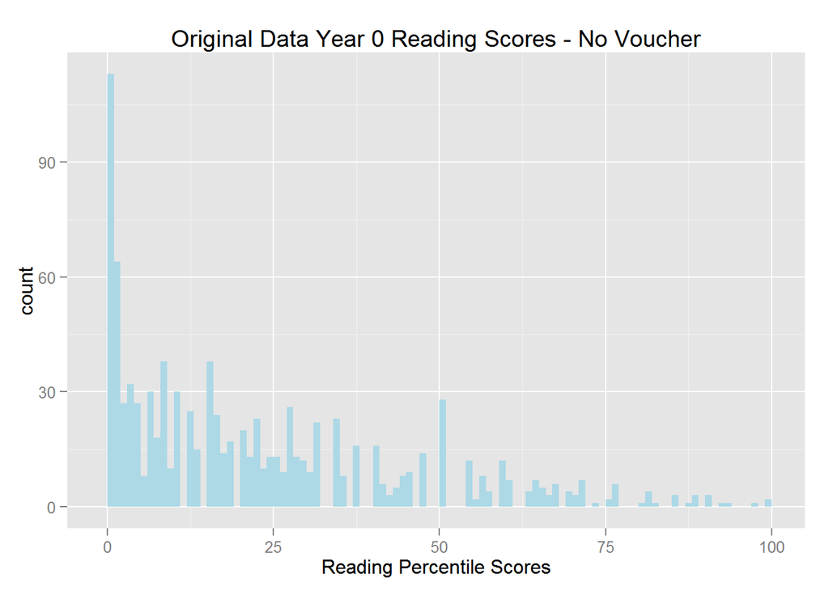

```r
nyc.no.vouch <- filter(nyc,Treatment=="1")
nyc.vouch <- filter(nyc,Treatment=="0")
qplot(nyc.no.vouch$y0_read_percentile,geom = "histogram", binwidth = 1.0, main = "Original Data Year 0 Reading Scores - No Voucher", xlab = "Reading Percentile Scores", fill=I("lightblue"))
```

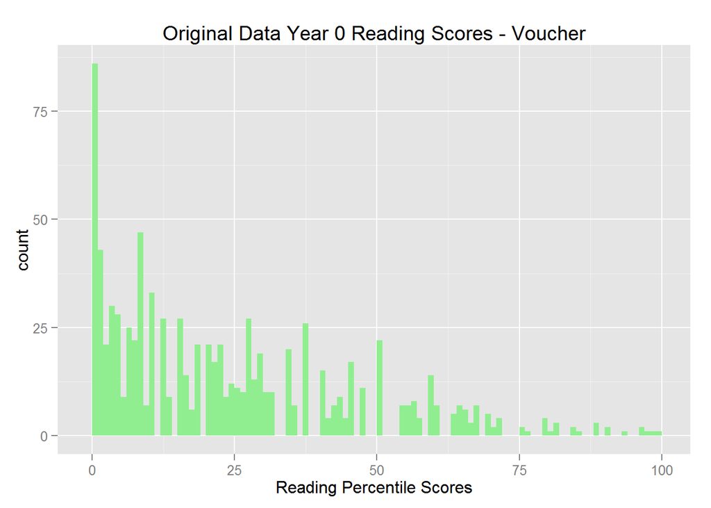

```r
qplot(nyc.vouch$y0_read_percentile,geom = "histogram", binwidth = 1.0, main = "Original Data Year 0 Reading Scores - Voucher", xlab = "Reading Percentile Scores", fill=I("lightgreen"))
```

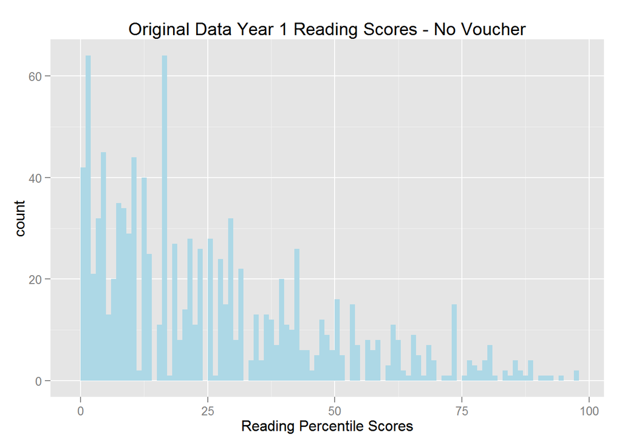

```r
qplot(nyc.no.vouch$y1_read_percentile,geom = "histogram", binwidth = 1.0, main = "Original Data Year 1 Reading Scores - No Voucher", xlab = "Reading Percentile Scores", fill=I("lightblue"))
```

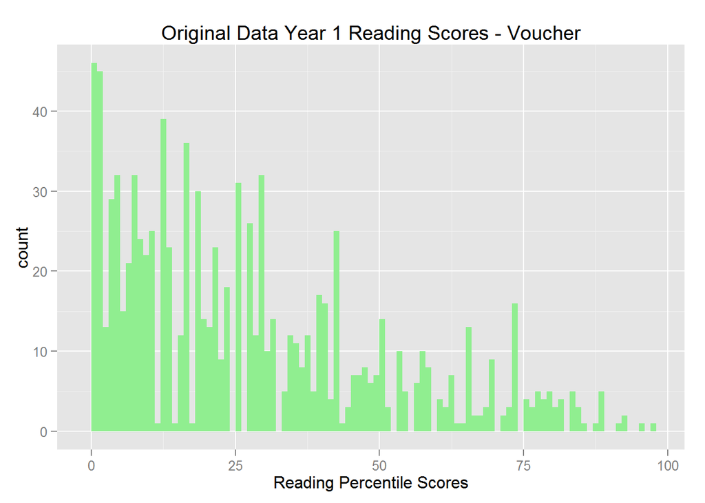

```r
qplot(nyc.vouch$y1_read_percentile,geom = "histogram", binwidth = 1.0, main = "Original Data Year 1 Reading Scores - Voucher", xlab = "Reading Percentile Scores", fill=I("lightgreen"))
```

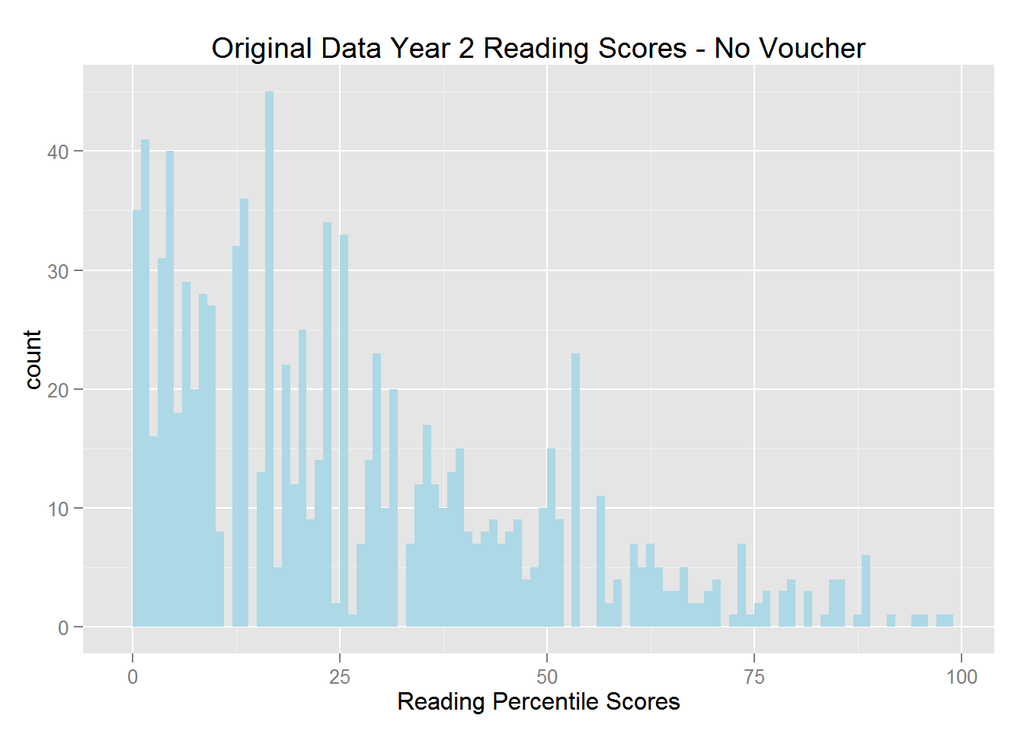

```r
qplot(nyc.no.vouch$y2_read_percentile,geom = "histogram", binwidth = 1.0, main = "Original Data Year 2 Reading Scores - No Voucher", xlab = "Reading Percentile Scores", fill=I("lightblue"))
```

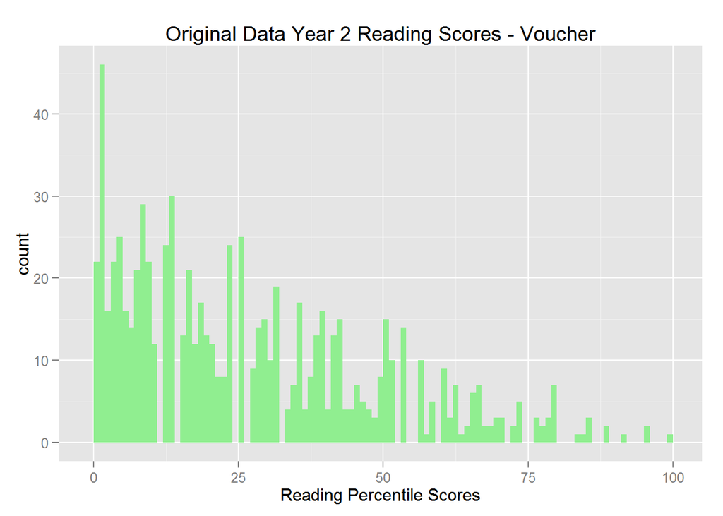

```r
qplot(nyc.vouch$y2_read_percentile,geom = "histogram", binwidth = 1.0, main = "Original Data Year 2 Reading Scores - Voucher", xlab = "Reading Percentile Scores", fill=I("lightgreen"))
```

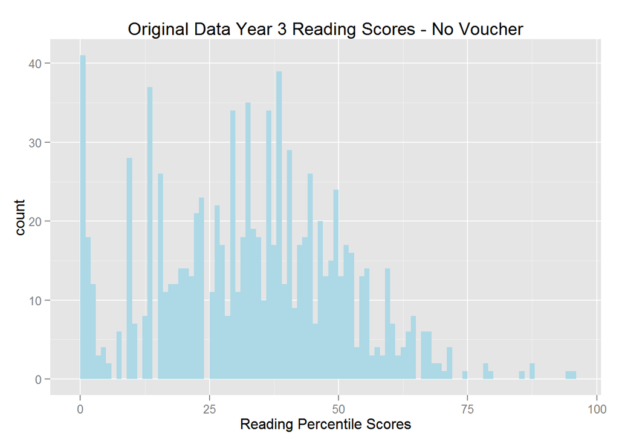

```r
qplot(nyc.no.vouch$y3_read_percentile,geom = "histogram", binwidth = 1.0, main = "Original Data Year 3 Reading Scores - No Voucher", xlab = "Reading Percentile Scores", fill=I("lightblue"))
```

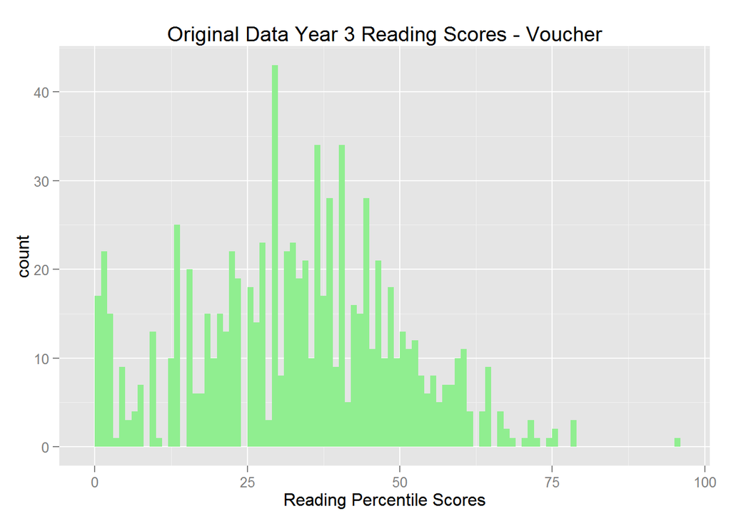

```r
qplot(nyc.vouch$y3_read_percentile,geom = "histogram", binwidth = 1.0, main = "Original Data Year 3 Reading Scores - Voucher", xlab = "Reading Percentile Scores", fill=I("lightgreen"))
```

**4. (4 points) In no more than 2-3 sentences, describe what your visualization in 1.C indicates about these data. Do the treatment and control groups appear to be similar (in terms of reading pre-test scores)? Why or why not?**

```r
summary(clean.vouch$y0_read_percentile)
```

```
##    Min. 1st Qu.  Median    Mean 3rd Qu.    Max.
##    0.00    6.00   18.00   23.54   37.00   97.00
```

```r
summary(clean.no.vouch$y0_read_percentile)
```

```
##    Min. 1st Qu.  Median    Mean 3rd Qu.    Max.
##    0.00    3.00   15.00   21.73   34.00   99.00
```

```r
summary(nyc.vouch$y0_read_percentile)
```

```
##    Min. 1st Qu.  Median    Mean 3rd Qu.    Max.    NA's
##     0.0     6.0    18.0    23.4    37.0    99.0     404
```

```r
summary(nyc.no.vouch$y0_read_percentile)
```

```
##    Min. 1st Qu.  Median    Mean 3rd Qu.    Max.    NA's
##    0.00    4.00   16.00   22.21   34.00   99.00     411
```

Looking at the histograms and summary statistics for pre-test reading scores of both the “dirty”" and clean data, it appears that the groups are similar despite slightly higher dispersion in the no.voucher set. Regardless, they appear to be a good match for comparing and isolating the effect of the voucher using test scores (even though we are not necessarily discussing causality at this point). Additionally, this comparability appears to hold for years 1, 2, and 3.

**5. (4 points) Typically, policy experiments such as the NYC school voucher lottery experiment are indended to produce statistical evidence that can then be generalized to broader policy applications (i.e., how might vouchers influence educational outcomes for other students who weren’t part of the original experiment). Based on the reading pre-test scores that you visualized in C, describe any concerns you might have about our ability to generalize the results of this experiment to ALL elementary school students in the United States in no more than 2-3 sentences.**

I have concerns about the situation of the mean. Test scores are usually normally distributed; this is not the case in this sample. There is an obvious and consistent right skew and the mean is nowhere near the 50th %ile leading me to conclude that this sample is not a representative sample of ALL elementary school students. I have suspicions that this experiment is being conducted on a specific target group that is different from average elementary school students. The “saving grace” is that the Central Limit Theorem applies; I can (and will) use the sample means; they are normally distributed.

**6. (4 points) What is the probability that a randomly selected student in the dataset received a voucher and scored above the 50th percentile on the math pre-test?**

```r
table(nyc$Treatment,nyc$y0_math_percentile > 50)
```

```
##
##     FALSE TRUE
##   0   824   64
##   1   896   67
```

```r
(896+67) / (824+64+896+67)  # P(voucher) = 0.5202593
```

```
## [1] 0.5202593
```

```r
(64+67)/(624+50+896+67)  # P(y0_math_percentile >50) = 0.08002443
```

```
## [1] 0.08002443
```

```r
0.5202593 * 0.08002443 # Method 1
```

```
## [1] 0.04163345
```

```r
67/(624+50+896+67) #Method 2
```

```
## [1] 0.04092853
```

The probability that a randomly selected student in the data set received a voucher and scored above the 50th percentile on the math pre-test is approximately 0.041 (Method 1 = 0.04163345 or Method 2 = 0.04092853).

**7. (4 points) What is the probability that a randomly selected student who received a voucher scored above the 50th percentile on the math pre-test?**

```r
table(clean.nyc$Treatment,clean.nyc$y0_math_percentile > 50)
```

```
##
##     FALSE TRUE
##   0   624   50
##   1   728   53
```

```r
53/(728+53) #Cleaned Data probability = 0.06786172
```

```
## [1] 0.06786172
```

```r
table(nyc$Treatment,nyc$y0_math_percentile > 50)
```

```
##
##     FALSE TRUE
##   0   824   64
##   1   896   67
```

```r
67/(896+67) #Full Data probability = 0.06957425
```

```
## [1] 0.06957425
```

```r
(896+67) / (824+64+896+67)  # P(voucher) = 0.5202593
```

```
## [1] 0.5202593
```

```r
0.5202593 * 0.06957425
```

```
## [1] 0.03619665
```

The probability that a randomly selected student who received a voucher scored above the 50th percentile on the math pre-test is approximately 0.070 (0.06786172 or 0.06957425 depending on the data used).

**8. (4 points) We are interested in studying whether the change in math scores after one year is different for students who receive a voucher versus those who do not. Write the null and alternative hypotheses in words and then using symbols.**

Null: *After one year, there is no average difference in math scores between students who receive vouchers and those who do not.*

$H_0$: [$\mu_{math.vouch.y1}$ - $\mu_{math.vouch.y0}$] - [$\mu_{math.no.vouch.y1}$ - $\mu_{math.no.vouch.y0}$] $= 0$

Alternative: *After one year, there is an average difference in math scores between students who receive vouchers and those who do not.*

$H_A$: [$\mu_{math.vouch.y1}$ - $\mu_{math.vouch.y0}$] - [$\mu_{math.no.vouch.y1}$ - $\mu_{math.no.vouch.y0}$] $\ne 0$

**9. (6 points) Evaluate the hypothesis from 1.H at a significance level of $\alpha = 0.05$ and state your conclusion in 1-2 sentences.**

```r
mean(clean.vouch$y1_math_percentile)
```

```
## [1] 23.04451
```

```r
sd(clean.vouch$y1_math_percentile)
```

```
## [1] 23.33714
```

```r
length(clean.vouch$y1_math_percentile)
```

```
## [1] 674
```

```r
mean(clean.vouch$y0_math_percentile)
```

```
## [1] 16.55786
```

```r
sd(clean.vouch$y0_math_percentile)
```

```
## [1] 19.28284
```

```r
length(clean.vouch$y0_math_percentile)
```

```
## [1] 674
```

```r
mdiff.vouch <- mean(clean.vouch$y1_math_percentile) - mean(clean.vouch$y0_math_percentile);print(mdiff.vouch)
```

```
## [1] 6.486647
```

```r
SE.mdiff.vouch <- sqrt(sd(clean.vouch$y0_math_percentile)^2/length(clean.vouch$y0_math_percentile) + sd(clean.vouch$y1_math_percentile)^2/length(clean.vouch$y1_math_percentile));print(SE.mdiff.vouch)
```

```
## [1] 1.16607
```

```r
mean(clean.no.vouch$y1_math_percentile)
```

```
## [1] 23.40333
```

```r
sd(clean.no.vouch$y1_math_percentile)
```

```
## [1] 22.01485
```

```r
length(clean.no.vouch$y1_math_percentile)
```

```
## [1] 781
```

```r
mean(clean.no.vouch$y0_math_percentile)
```

```
## [1] 16.29834
```

```r
sd(clean.no.vouch$y0_math_percentile)
```

```
## [1] 19.15495
```

```r
length(clean.no.vouch$y0_math_percentile)
```

```
## [1] 781
```

```r
mdiff.no.vouch <- mean(clean.no.vouch$y1_math_percentile) - mean(clean.no.vouch$y0_math_percentile);print(mdiff.no.vouch)
```

```
## [1] 7.104994
```

```r
SE.mdiff.no.vouch <- sqrt(sd(clean.no.vouch$y0_math_percentile)^2/length(clean.no.vouch$y0_math_percentile) + sd(clean.no.vouch$y1_math_percentile)^2/length(clean.no.vouch$y1_math_percentile));print(SE.mdiff.no.vouch)
```

```
## [1] 1.0442
```

```r
diff.of.means <- mdiff.vouch - mdiff.no.vouch;print(diff.of.means)
```

```
## [1] -0.6183467
```

```r
SE.diff.of.means <- sqrt(SE.mdiff.vouch^2 + SE.mdiff.no.vouch^2); print(SE.diff.of.means)
```

```
## [1] 1.56527
```

```r
t.obs <- diff.of.means - 0/SE.diff.of.means;print(t.obs)
```

```
## [1] -0.6183467
```

```r
# t.obs = -0.6183467 or |-0.6183467| = 0.6183467

#Let's try it with the t.test function
t.test(clean.nyc$y1_math_percentile[clean.nyc$Treatment=="1"] - clean.nyc$y0_math_percentile[clean.nyc$Treatment=="1"], clean.nyc$y1_math_percentile[clean.nyc$Treatment=="0"] - clean.nyc$y0_math_percentile[clean.nyc$Treatment=="0"])
```

```
##
##  Welch Two Sample t-test
##
## data:  clean.nyc$y1_math_percentile[clean.nyc$Treatment == "1"] - clean.nyc$y0_math_percentile[clean.nyc$Treatment ==  and clean.nyc$y1_math_percentile[clean.nyc$Treatment == "0"] - clean.nyc$y0_math_percentile[clean.nyc$Treatment ==     "1"] and     "0"]
## t = 0.58291, df = 1385.5, p-value = 0.5601
## alternative hypothesis: true difference in means is not equal to 0
## 95 percent confidence interval:
##  -1.462600  2.699293
## sample estimates:
## mean of x mean of y
##  7.104994  6.486647
```

We can fail to reject the null because the $p_{obs}$ > $p_{0.05/2}$. Based on these statistics, there is good evidence that there is not a significant difference in the average year 1 math scores of students who received vouchers and those who did not.

**10. (2 points) Would your conclusion change at $\alpha = 0.10$? Why or why not?**

```r
t.test(clean.nyc$y1_math_percentile[clean.nyc$Treatment=="1"], clean.nyc$y1_math_percentile[clean.nyc$Treatment=="0"], conf.level = 0.90)
```

```
##
##  Welch Two Sample t-test
##
## data:  clean.nyc$y1_math_percentile[clean.nyc$Treatment == "1"] and clean.nyc$y1_math_percentile[clean.nyc$Treatment == "0"]
## t = 0.30021, df = 1394.2, p-value = 0.7641
## alternative hypothesis: true difference in means is not equal to 0
## 90 percent confidence interval:
##  -1.608484  2.326122
## sample estimates:
## mean of x mean of y
##  23.40333  23.04451
```

We can still fail to reject the null because the $p_{obs}$ > $p_{0.10/2}$. Based on these statistics, there is good evidence that there is not a significant difference in the average year 1 math scores of students who received vouchers and those who did not. The difference we do observe is the equivalent to several tenths of a percentage point and is not statistically different from 0.

**11. (6 points) There are four assumptions that hold for the test above to be valid: independence within groups, independence between groups, sample sizes both above 30, and symmetric distributions. Are you satisfied that each of these are upheld? Is there anything in particular that you might be concerned about?**

```r
table(clean.nyc$Treatment)
```

```
##
##   0   1
## 674 781
```

```r
674/(674+781)
```

```
## [1] 0.4632302
```

```r
781/(674+781)
```

```
## [1] 0.5367698
```

```r
table(nyc$Treatment)
```

```
##
##    0    1
## 1292 1374
```

```r
1291/(1291+1374)
```

```
## [1] 0.4844278
```

```r
1374/(1291+1374)
```

```
## [1] 0.5155722
```

Because this is an experiment, I am making the assumption that there was both random selection and random assignment in regards to voucher assignment (Clean Data Treatment vs.Control; np =0.4632302, 1-np = 0.5367698 versus Full Data Treatment vs. Control; np = 0.4844278, 1-np = 0.5155722). Assuming the differences in the proportions is not statistically significant, this satisfies the required condition of between group independence because each student had the same probability of being selected for a voucher. Likewise, being selected for Treatment should have no relation to those in the other group; there is nothing to alert us that there is some pre-existing attribute that increases thee chance of a person being in one group or the other. Both the treatment and control groups meet the condition of n >30.

These distributions are not symmetrical; I addressed this earlier when I discussed the possibility that the normal model may not necessarily apply because of the strong and consistent right skew in the data. The data do not even approach normality until Year 3. Therefore, any conclusion we come to about the impact or lack of impact of the vouchers needs to be tempered in light of this skew and the inability of the normal model to accurately describe this data.

**12. (4 points) Next, you are asked to evaluate whether students in the treatment group differ in terms of their reading ability from the pre-test to the year 1 post-test. Write out the null and alternative hypotheses in words and then in symbols.**

Null: *There is no average difference in Year 0 pre-test and Year 1 post-test reading ability between students who receive vouchers and those who do not.*

$H_0$: [$\mu_{read.vouch.y1}$ - $\mu_{read.vouch.y0}$] - [$\mu_{read.no.vouch.y1}$ - $\mu_{read.no.vouch.y0}$] $= 0$

Alternative: *There is an average difference in Year 0 pre-test and Year 1 post-test reading ability between students who receive vouchers and those who do not.*

$H_A$: [$\mu_{read.vouch.y1}$ - $\mu_{read.vouch.y0}$] - [$\mu_{read.no.vouch.y1}$ - $\mu_{read.no.vouch.y0}$] $\ne 0$

**13. (6 points) Conduct a t-test to evaluate this hypothesis at $\alpha = 0.01$ significance level. Interpret your results in 1-2 complete sentences.**

```r
mean(clean.vouch$y1_read_percentile)
```

```
## [1] 24.80564
```

```r
sd(clean.vouch$y1_read_percentile)
```

```
## [1] 21.47778
```

```r
length(clean.vouch$y1_read_percentile)
```

```
## [1] 674
```

```r
mean(clean.vouch$y0_read_percentile)
```

```
## [1] 23.54006
```

```r
sd(clean.vouch$y0_read_percentile)
```

```
## [1] 21.33938
```

```r
length(clean.vouch$y0_read_percentile)
```

```
## [1] 674
```

```r
mdiff.vouch <- mean(clean.vouch$y1_read_percentile) - mean(clean.vouch$y0_read_percentile);print(mdiff.vouch)
```

```
## [1] 1.265579
```

```r
SE.mdiff.vouch <- sqrt(sd(clean.vouch$y0_read_percentile)^2/length(clean.vouch$y0_read_percentile) + sd(clean.vouch$y1_read_percentile)^2/length(clean.vouch$y1_read_percentile));print(SE.mdiff.vouch)
```

```
## [1] 1.166206
```

```r
mean(clean.no.vouch$y1_read_percentile)
```

```
## [1] 24.47503
```

```r
sd(clean.no.vouch$y1_read_percentile)
```

```
## [1] 21.39305
```

```r
length(clean.no.vouch$y1_read_percentile)
```

```
## [1] 781
```

```r
mean(clean.no.vouch$y0_read_percentile)
```

```
## [1] 21.72855
```

```r
sd(clean.no.vouch$y0_read_percentile)
```

```
## [1] 21.74056
```

```r
length(clean.no.vouch$y0_read_percentile)
```

```
## [1] 781
```

```r
mdiff.no.vouch <- mean(clean.no.vouch$y1_read_percentile) - mean(clean.no.vouch$y0_read_percentile);print(mdiff.no.vouch)
```

```
## [1] 2.746479
```

```r
SE.mdiff.no.vouch <- sqrt(sd(clean.no.vouch$y0_read_percentile)^2/length(clean.no.vouch$y0_read_percentile) + sd(clean.no.vouch$y1_read_percentile)^2/length(clean.no.vouch$y1_read_percentile));print(SE.mdiff.no.vouch)
```

```
## [1] 1.091414
```

```r
diff.of.means <- mdiff.vouch - mdiff.no.vouch - 0;print(diff.of.means)
```

```
## [1] -1.4809
```

```r
SE.diff.of.means <- sqrt(SE.mdiff.vouch^2 + SE.mdiff.no.vouch^2); print(SE.diff.of.means)
```

```
## [1] 1.597254
```

```r
t.obs <- diff.of.means - 0/SE.diff.of.means;print(t.obs)
```

```
## [1] -1.4809
```

```r
# t.obs = -1.4809

#Let's try it with the t.test function
t.test(clean.nyc$y1_read_percentile[clean.nyc$Treatment=="1"] - clean.nyc$y0_read_percentile[clean.nyc$Treatment=="1"], clean.nyc$y1_read_percentile[clean.nyc$Treatment=="0"] - clean.nyc$y0_read_percentile[clean.nyc$Treatment=="0"])
```

```
##
##  Welch Two Sample t-test
##
## data:  clean.nyc$y1_read_percentile[clean.nyc$Treatment == "1"] - clean.nyc$y0_read_percentile[clean.nyc$Treatment ==  and clean.nyc$y1_read_percentile[clean.nyc$Treatment == "0"] - clean.nyc$y0_read_percentile[clean.nyc$Treatment ==     "1"] and     "0"]
## t = 1.4506, df = 1426.1, p-value = 0.1471
## alternative hypothesis: true difference in means is not equal to 0
## 95 percent confidence interval:
##  -0.5216447  3.4834452
## sample estimates:
## mean of x mean of y
##  2.746479  1.265579
```

We fail to reject the null because the $p_{obs} > p_{0.05/2}$. Based on these statistics, there is good evidence that there is no average difference in Year 0 pre-test and Year 1 post-test reading ability between students who receive vouchers and those who do not.

**14. (4 points) Explain how you could evaluate the hypothesis above using a confidence interval instead of a p-value.**

```r
# GUIDE: mean point estimate + qt(p, df, lower.tail = TRUE)
#If we are intrested in the 95% CI, then we need to look at the 2.5 %ile and the 97.5 %ile.
(2.746479 - 1.265579 -0) + qt(c(0.025,0.975),df=1426.1 ) * SE.diff.of.means
```

```
## [1] -1.652319  4.614119
```

```r
diff.of.means + qt(c(0.025,0.975),df=1426.1 ) * SE.diff.of.means
```

```
## [1] -4.614119  1.652319
```

I can use the Confidence Interval to estimate the range of values that include the true population average difference of the means at least 95% of the time. 5% of the time (and this could end up being be a non-trivial number) a sample will have a difference of means that does not include the true population average difference of means. This observation could be at the high end or at the low end of the distribution if we continue to assume normality.

**15. (2 points) Interpret the confidence interval you estimated for question N in a sentence.**

We can be 95% confident that the true value of the average difference in Year 0 pre-test and Year 1 post-test reading ability between students who receive vouchers and those who do not is between -4.614119 and 1.652319 ($-4.614119$ < $\mu_{diff.of.means}$ < $1.652319$).

**16. (8 points) Perform a test of whether the average math pre-test score differs by grade level at $\alpha = 0.10$ significance level. Write out your hypothesis in symbols, perform the test, and then report your findings in a complete sentence.**

Null: *There is no average difference in Year 0 pre-test math scores between students in grades Kindergarten through 5.*

$H_0$: $\mu_{Kinder.y0}$ = $\mu_{grade1.y0}$ = $\mu_{grade2.y0}$ = $\mu_{grade3.y0}$ = $\mu_{grade4.y0}$ = $\mu_{grade5.y0}$ $= 0$

Alternative: *There is an average difference in Year 0 pre-test math scores between students in grades Kindergarten through 5.*

$H_A$: $\mu_{Kinder.y0}$ $\ne$ $\mu_{grade1.y0}$ $\ne$ $\mu_{grade2.y0}$ $\ne$ $\mu_{grade3.y0}$ $\ne$ $\mu_{grade4.y0}$ $\ne$ $\mu_{grade5.y0}$ $\ne 0$

```r
table(clean.nyc$Grade)
```

```
##
##  -7   0   1   2   3   4   5
##  24   3 350 377 379 280   4
```

```r
Kinder <- filter(clean.nyc, Grade=="0")
grade1 <- filter(clean.nyc, Grade=="1")
grade2 <- filter(clean.nyc, Grade=="2")
grade3 <- filter(clean.nyc, Grade=="3")
grade4 <- filter(clean.nyc, Grade=="4")
grade5 <- filter(clean.nyc, Grade=="5")

Kinder.mean <- mean(Kinder$y0_math_percentile); print(Kinder.mean)
```

```
## [1] 3
```

```r
Kinder.sd <- sd(Kinder$y0_math_percentile); print(Kinder.sd)
```

```
## [1] 3
```

```r
grade1.mean <- mean(grade1$y0_math_percentile); print(grade1.mean)
```

```
## [1] 10.83429
```

```r
grade1.sd <- sd(grade1$y0_math_percentile); print(grade1.sd)
```

```
## [1] 14.06314
```

```r
grade2.mean <- mean(grade2$y0_math_percentile); print(grade2.mean)
```

```
## [1] 18.9496
```

```r
grade2.sd <- sd(grade2$y0_math_percentile); print(grade2.sd)
```

```
## [1] 18.93593
```

```r
grade3.mean <- mean(grade3$y0_math_percentile); print(grade3.mean)
```

```
## [1] 16.1504
```

```r
grade3.sd <- sd(grade3$y0_math_percentile); print(grade3.sd)
```

```
## [1] 19.1389
```

```r
grade4.mean <- mean(grade4$y0_math_percentile); print(grade4.mean)
```

```
## [1] 20.74286
```

```r
grade4.sd <- sd(grade4$y0_math_percentile); print(grade4.sd)
```

```
## [1] 23.14776
```

```r
grade5.mean <- mean(grade5$y0_math_percentile); print(grade5.mean)
```

```
## [1] 29.75
```

```r
grade5.sd <- sd(grade5$y0_math_percentile); print(grade5.sd)
```

```
## [1] 31.30894
```

```r
summary(aov(y0_math_percentile~Grade,clean.nyc),conf.level=0.90)
```

```
##               Df Sum Sq Mean Sq F value  Pr(>F)
## Grade          1   5804    5804    15.9 0.00007 ***
## Residuals   1415 516356     365
## ---
## Signif. codes:  0 '***' 0.001 '**' 0.01 '*' 0.05 '.' 0.1 ' ' 1
## 38 observations deleted due to missingness
```

```r
summary.aov(lm(y0_math_percentile~Grade,clean.nyc),conf.level=0.90)
```

```
##               Df Sum Sq Mean Sq F value  Pr(>F)
## Grade          1   5804    5804    15.9 0.00007 ***
## Residuals   1415 516356     365
## ---
## Signif. codes:  0 '***' 0.001 '**' 0.01 '*' 0.05 '.' 0.1 ' ' 1
## 38 observations deleted due to missingness
```

```r
0.05/6
```

```
## [1] 0.008333333
```

```r
0.10/6
```

```
## [1] 0.01666667
```

```r
pairwise.t.test(x=clean.nyc$y0_math_percentile,g = clean.nyc$Grade,p.adjust.method = 'bonf')
```

```
##
##  Pairwise comparisons using t tests with pooled SD
##
## data:  clean.nyc$y0_math_percentile and clean.nyc$Grade
##
##   -7     0      1            2      3      4
## 0 1.0000 -      -            -      -      -
## 1 1.0000 1.0000 -            -      -      -
## 2 1.0000 1.0000 0.0000001793 -      -      -
## 3 1.0000 1.0000 0.0032       0.8746 -      -
## 4 1.0000 1.0000 0.0000000017 1.0000 0.0432 -
## 5 1.0000 1.0000 0.9755       1.0000 1.0000 1.0000
##
## P value adjustment method: bonferroni
```

```r
#This test shows us where the differences occur. This is more than the question asked but is something I would like to know. It can indicate upward progress if the kids are tracked.
```

**17. (8 points) The NYC School District considers students who perform at or above the 50th percentile to be “passing”. At a 99% significance level, is the proportion of all students in the sample (voucher and no-voucher) that are considered to be passing in math significantly different between the pre-test and year 1 post-test?**

Null: *There is no significant difference in the proportion of students considered to be passing between Year 0 pre-test math scores and Year 1 post-test math scores.*

$H_0$: $\Pi_{Math}^0$ = $\Pi_{Math}^1$

Alternative: *There is a significant difference in the proportion of students considered to be passing between Year 0 pre-test math scores and Year 1 post-test math scores.*

$H_A$: $\Pi_{Math}^0$ $\ne$ $\Pi_{Math}^1$

```r
table(nyc$y0_math_percentile >=50)
```

```
##
## FALSE  TRUE
##  1707   144
```

```r
Year0.50plus.hat = 144/(1707+144);print(Year0.50plus.hat)
```

```
## [1] 0.07779579
```

```r
Year0.50plus.n = 1707+144
table(nyc$y1_math_percentile >= 50)
```

```
##
## FALSE  TRUE
##  1806   274
```

```r
Year1.50plus.hat = 274/(1806+274);print(Year1.50plus.hat)
```

```
## [1] 0.1317308
```

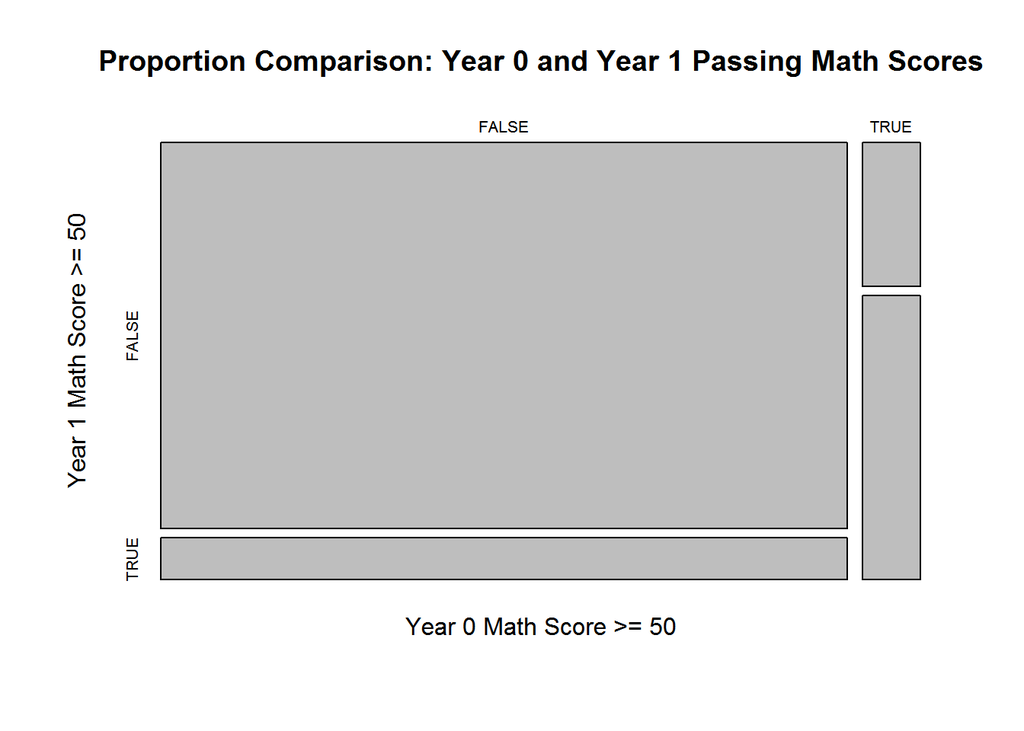

```r
Year1.50plus.n = 1806+274

plot(table(nyc$y0_math_percentile>=50,nyc$y1_math_percentile>=50), main="Proportion Comparison: Year 0 and Year 1 Passing Math Scores", xlab="Year 0 Math Score >= 50", ylab="Year 1 Math Score >= 50")
```

```r
# SE pool FORMULA: sqrt [pi hat1(1-pi hat1)/n1 + pi hat2(1-pi hat2)/n2]
# CI FORMULA: (pi hat2 - pi hat1) + - z(SE pool)
# z = (pi hat2 - pi hat1) - 0/ SE pool
prop.test(x=c(Year0.50plus.n*Year0.50plus.hat,Year1.50plus.n*Year1.50plus.hat), n = c(Year0.50plus.n,Year1.50plus.n),alternative = c("two.sided"),conf.level = 0.99,correct = TRUE)
```

```
##
##  2-sample test for equality of proportions with continuity
##  correction
##
## data:  c(Year0.50plus.n * Year0.50plus.hat, Year1.50plus.n * Year1.50plus.hat) out of c(Year0.50plus.n, Year1.50plus.n)
## X-squared = 29.417, df = 1, p-value = 0.00000005836
## alternative hypothesis: two.sided
## 99 percent confidence interval:
##  -0.07938568 -0.02848429
## sample estimates:
##     prop 1     prop 2
## 0.07779579 0.13173077
```

With an observed probability of $p_{obs} = 0.00000005836$ < $p = 0.01$ we reject the null; the proportion of all students in the sample (voucher and no-voucher) that are considered to be passing in math is significantly different between the Year 0 pre-test and Year 1 post-test.

**18. (6 points) Make a boxplot that compares the distribution of math scores between the pre-test and year 1 post-test for all students. Do your best to make the figure “publishable” by giving it clear axis titles, legend labels, and other aesthetic improvements. In no more than 2-3 sentences, describe how your figure supports (or does not support) your finding from question 17.**

```r
summary(clean.nyc$y0_math_percentile)
```

```
##    Min. 1st Qu.  Median    Mean 3rd Qu.    Max.
##    0.00    2.00    9.00   16.42   25.00   98.00
```

```r
summary(clean.nyc$y1_math_percentile)
```

```
##    Min. 1st Qu.  Median    Mean 3rd Qu.    Max.
##    0.00    5.00   15.00   23.24   36.00   99.00
```

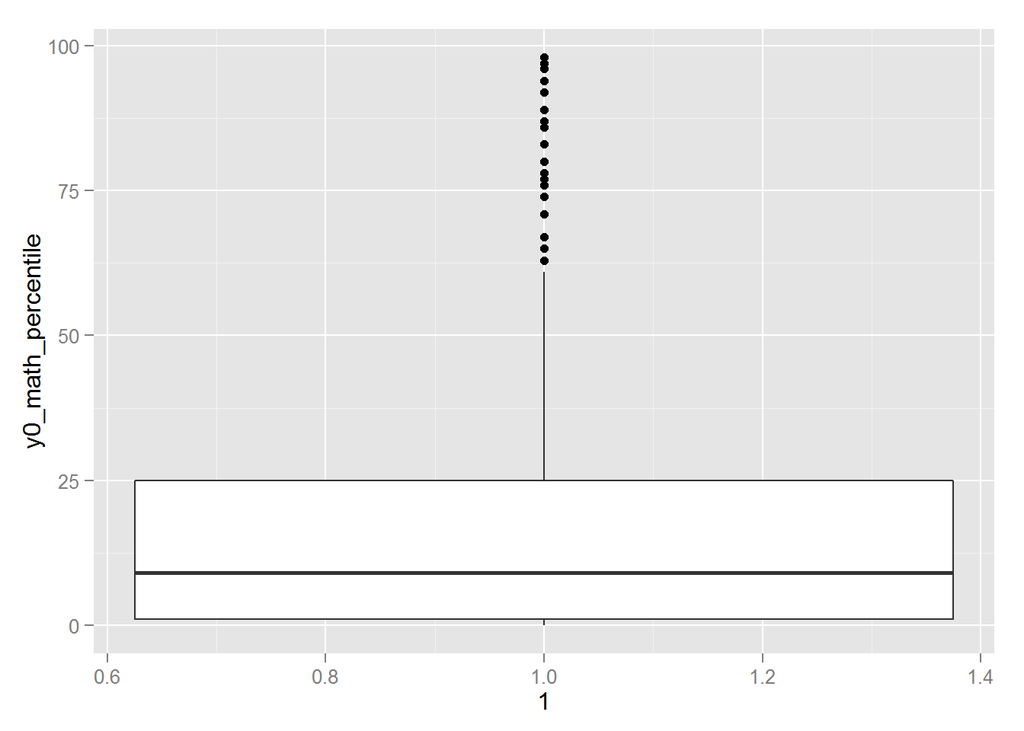

```r
ggplot(nyc, aes(y = y0_math_percentile, x = 1)) + geom_boxplot()
```

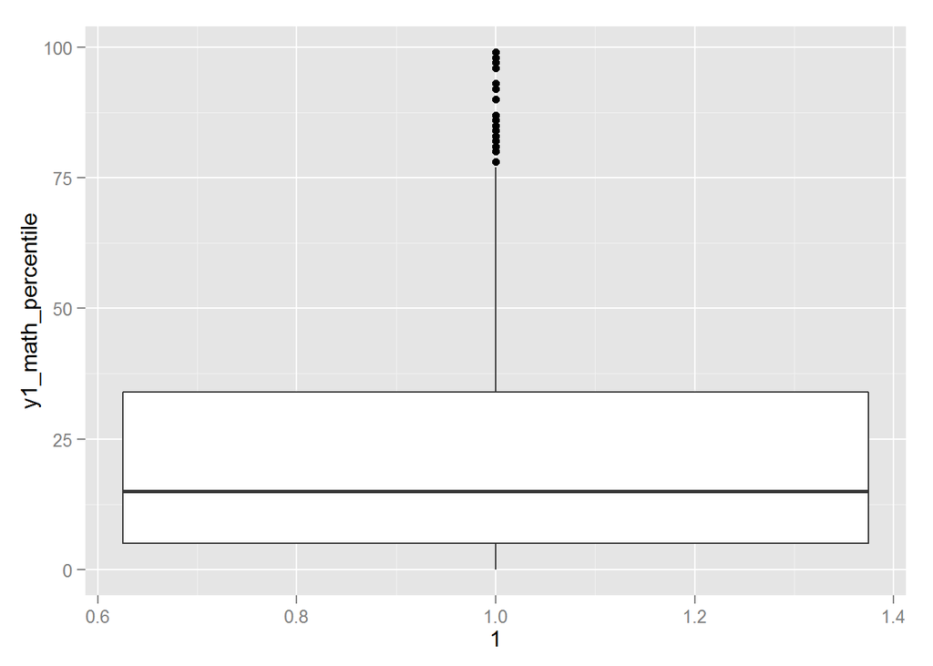

```r
ggplot(nyc, aes(y = y1_math_percentile, x = 1 )) + geom_boxplot()
```

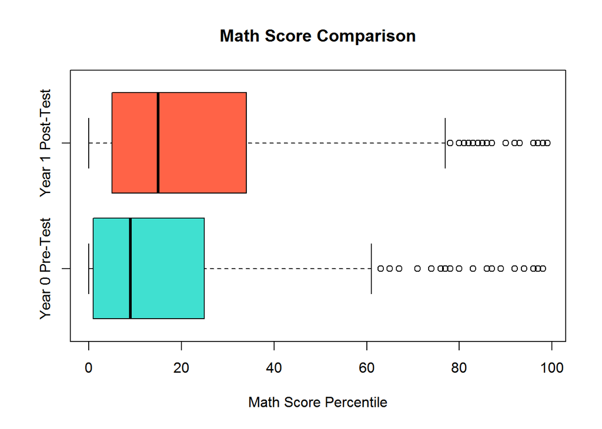

```r
boxplot(nyc$y0_math_percentile,nyc$y1_math_percentile,
        horizontal=TRUE,
        names=c("Year 0 Pre-Test","Year 1 Post-Test"),
        col=c("turquoise","tomato"),
        xlab="Math Score Percentile",
        main="Math Score Comparison")
```

The box plots support the conclusion that proportion of all students in the sample (voucher and no-voucher) that are considered to be passing in math is significantly different between the Year 0 pre-test and Year 1 post-test. There is a noticeable positive change from Year 0 to Year1 in the 1st Quartiles, the Medians, and the 3rd Quartiles. Additionally, the maximum value is significantly higher in Year1 than in Year0, excluding outliers, by approximately 15 percentage points.

These are just for fun…

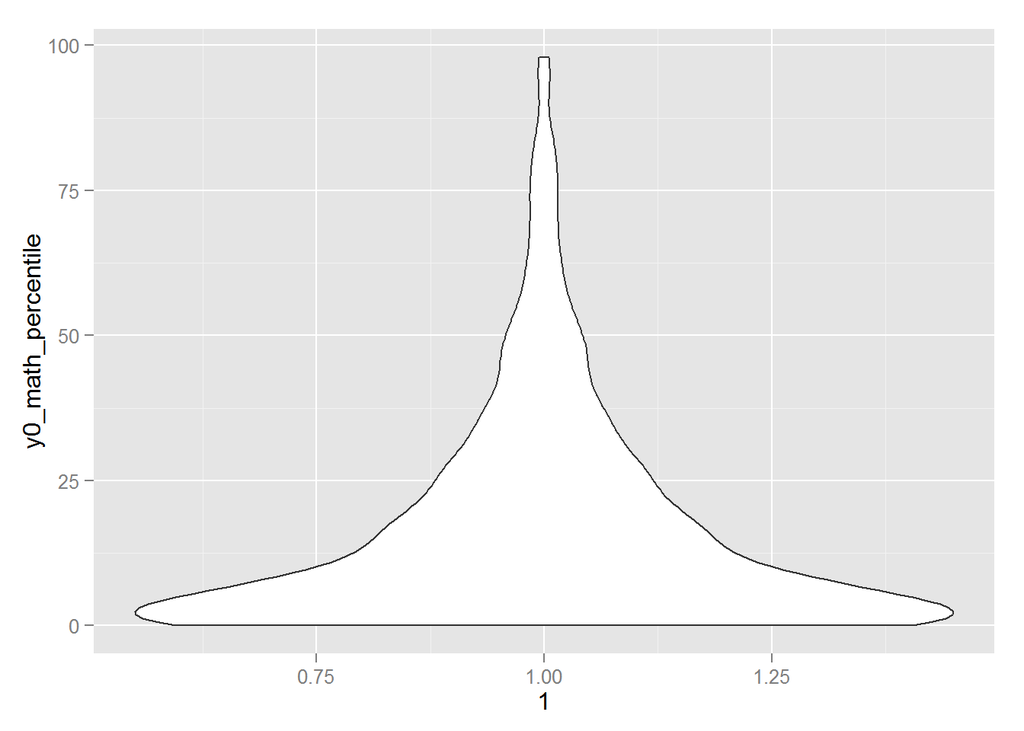

```r
ggplot(nyc, aes(y = y0_math_percentile, x = 1 )) + geom_violin()
```

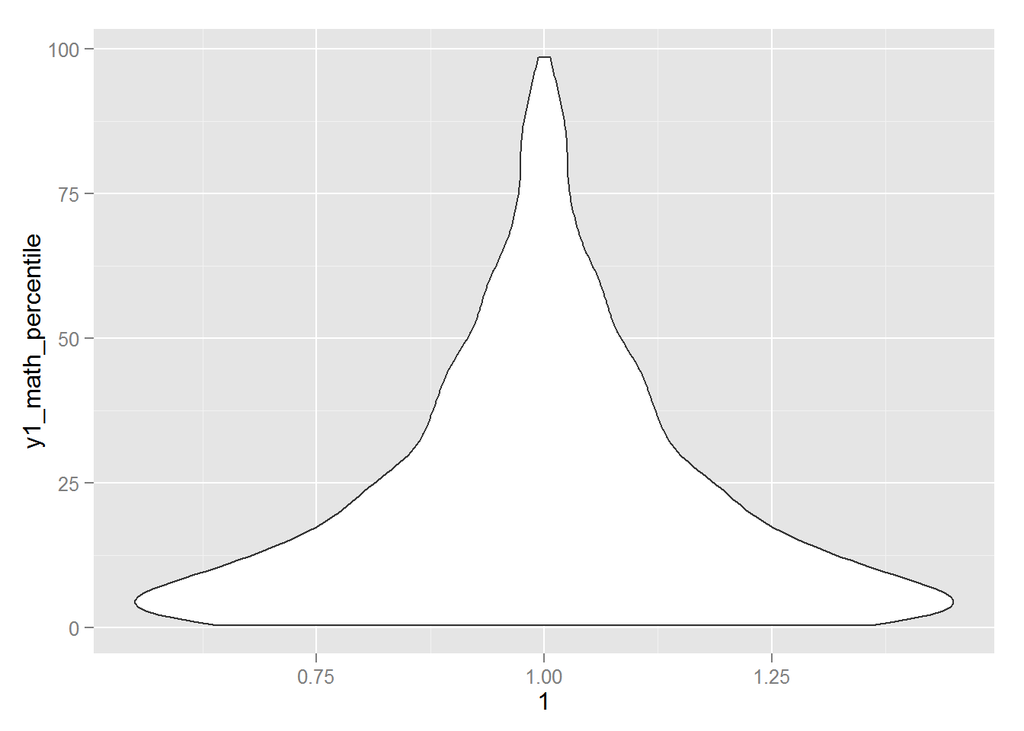

```r
ggplot(nyc, aes(y = y1_math_percentile, x = 1 )) + geom_violin()
```

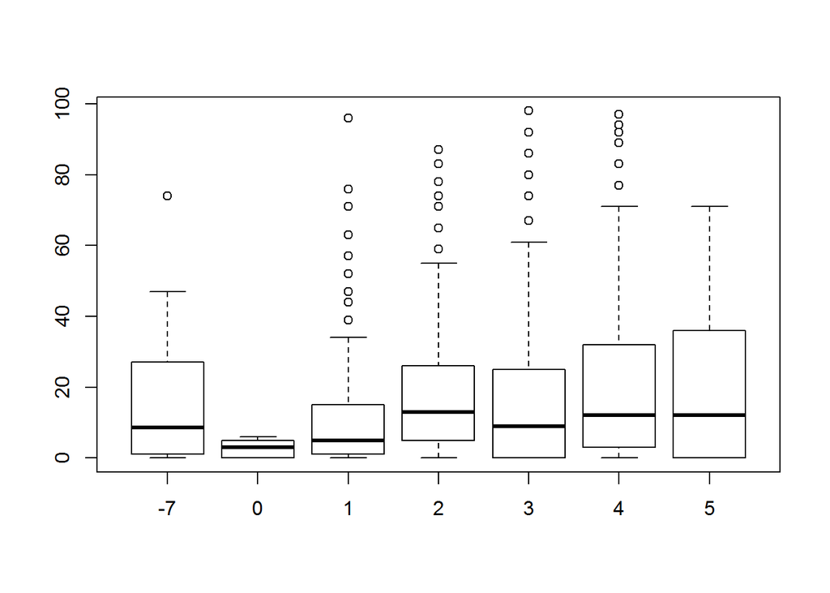

```r
boxplot(y0_math_percentile~Grade,data=nyc)
```

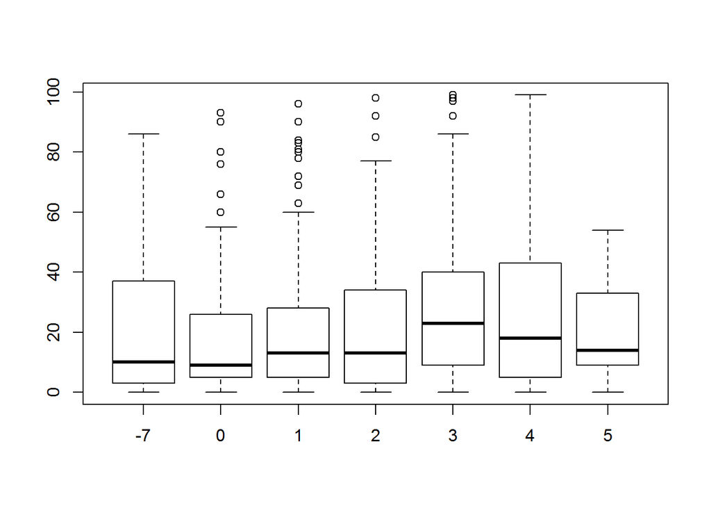

```r
boxplot(y1_math_percentile~Grade,data=nyc)
```

**19. (4 points) Consider the correlation between math percentile and reading percentile for year 1 test scores. Compute Pearson’s `r` between these two variables. Is the correlation higher or lower than you would have expected?**

```r
# clean.nyc$y1_math_percentile  clean.nyc$y1_read_percentile
#?cor()
# GUIDE: cor(x, y = NULL, use = "everything",method = c("pearson", "kendall", "spearman"))
cor(nyc$y1_math_percentile,nyc$y1_read_percentile,method = "pearson") #This won't  work because of the missing values; I need to use the clean data.
```

```
## [1] NA
```

```r
cor(clean.nyc$y1_math_percentile,clean.nyc$y1_read_percentile,method = "pearson")
```

```
## [1] 0.6164846
```

Using Pearson’s r, the correlation between Year 1 Math Scores and Year 1 Reading Scores is 0.6164846or 0.62. For every one unit increase in Year 1 Math Scores, there is a positive correlation in Year 1 Reading Scores of approximately 0.62 units. This is about what I expected considering my experience with the Get Georgia Reading campaign. They speak at length about the correlation between math scores and reading scores but from the reading perspective; for every 1 unit increase in reading scores, math scores increase 0.62 units. The whole idea is that math problems are actually reading problems beginning in 3rd grade when kids start to “read to learn”.

**20. (6 points) You might argue that percentiles are actually rank-order data and not ratio-level data. For rank-order data, a more appropriate correlation measure is Spearman’s $\Rho$, which is a rank correlation. Compute $\rho$ and contrast the results from $r$ (for question S above). Why do the results differ?**

```r
# This exercise is asking us to treat Year 1 Math Scores and Year 1 Reading Scores as ordinal, categorical variables instead of as discrete, numerical variables.
cor(clean.nyc$y1_math_percentile,clean.nyc$y1_read_percentile,method = "spearman")
```

```
## [1] 0.5848958
```

The correlation between Year 1 Math Scores and Year 1 Reading Score using Spearman’s $Rho$ is 0.5848958 or 0.58. For every one unit increase in Year 1 Math Scores, there is a positive correlation in Year 1 Reading Scores by approximately 0.58 units. This correlation estimate is approximately 0.04 less than the estimate using Pearson’s `r`.

The results from the Pearson’s `r` and Spearman’s $\rho$ differ because the Pearson’s `r` measures the strength of the linear relationship between normally distributed, interval(discrete or continuous) variables. I have repeatedly discussed the problems applying the normal model to this data; Spearman’s $\rho$ may be a more precise estimate of the correlation between Year 1 Math and Reading Scores because it does not require normality yet assumes a monotonic relationship between the ordinal variables (as the value of one variable increases, so does the value of the other variable; or as the value of one variable increases, the other variable value decreases).